# Empirical Bayes subject-wise fitting

This document demonstrates `ctEmpiricalBayesFit()` for a simple univariate continuous time process. The data contain 20 subjects, each with 80 equally spaced observations. The generating model varies across subjects in:

- `T0MEANS`: subject-specific initial latent level
- `DRIFT`: subject-specific autoregressive continuous time drift
- `DIFFUSION`: subject-specific process noise scale
- `MANIFESTMEANS`: subject-specific measurement intercept

## Simulate data

```r
library(ctsem)
library(ggplot2)

set.seed(49)

n_subjects <- 20
n_obs <- 80

raw_param_names <- c("t0m", "drift", "diffusion", "mmean")
raw_cor <- matrix(c(
   1.00,  0.45, -0.25,  0.35,
   0.45,  1.00, -0.55,  0.25,
  -0.25, -0.55,  1.00, -0.20,
   0.35,  0.25, -0.20,  1.00
), nrow = 4, byrow = TRUE,
dimnames = list(raw_param_names, raw_param_names))
raw_sd <- c(t0m = .7, drift = .55, diffusion = .35, mmean = 2.45)
raw_mean <- c(t0m = 0, drift = -.4, diffusion = log(exp(.45) - 1), mmean = 0)
raw_cov <- diag(raw_sd) %*% raw_cor %*% diag(raw_sd)
dimnames(raw_cov) <- dimnames(raw_cor)

# Each subject's raw parameters are drawn from this population by ctGenerate:
# RAWPOPVAR is the covariance of the raw (pre-transform) parameters, written
# from a covariance matrix by ctCov(), and values the population means on
# the natural scale.
gm <- ctModel(
  silent = TRUE,
  Tpoints = n_obs,
  latentNames = "eta",
  manifestNames = "Y",
  LAMBDA = matrix(1),
  T0MEANS = matrix("t0m|param|TRUE"),
  DRIFT = matrix("drift|-log1p_exp(-param)|TRUE"),
  DIFFUSION = matrix("diffusion|log1p_exp(param)|TRUE"),
  CINT = matrix(0),
  T0VAR = matrix(0),
  MANIFESTMEANS = matrix("mmean|param|TRUE"),
  MANIFESTVAR = matrix(.35)
)
gm$RAWPOPVAR <- ctCov(raw_cov)
softplus <- function(x) ifelse(x > 30, x, log1p(exp(x)))

generated <- ctGenerate(gm, n = n_subjects, dtmean = .1, backend = "julia",
  values = c(t0m = raw_mean[["t0m"]], drift = -softplus(-raw_mean[["drift"]]),
    diffusion = softplus(raw_mean[["diffusion"]]), mmean = raw_mean[["mmean"]]))

# The parameters each subject was generated with, on the natural scale, and
# back on the raw scale through the inverse transforms.
truth <- attr(generated, "subjectpars")[, c("id", raw_param_names)]
raw_truth <- data.frame(id = truth$id, t0m = truth$t0m,
  drift = -log(expm1(-truth$drift)), diffusion = log(expm1(truth$diffusion)),
  mmean = truth$mmean)

dat <- data.frame(generated)[, c("id", "time", "Y")]
```

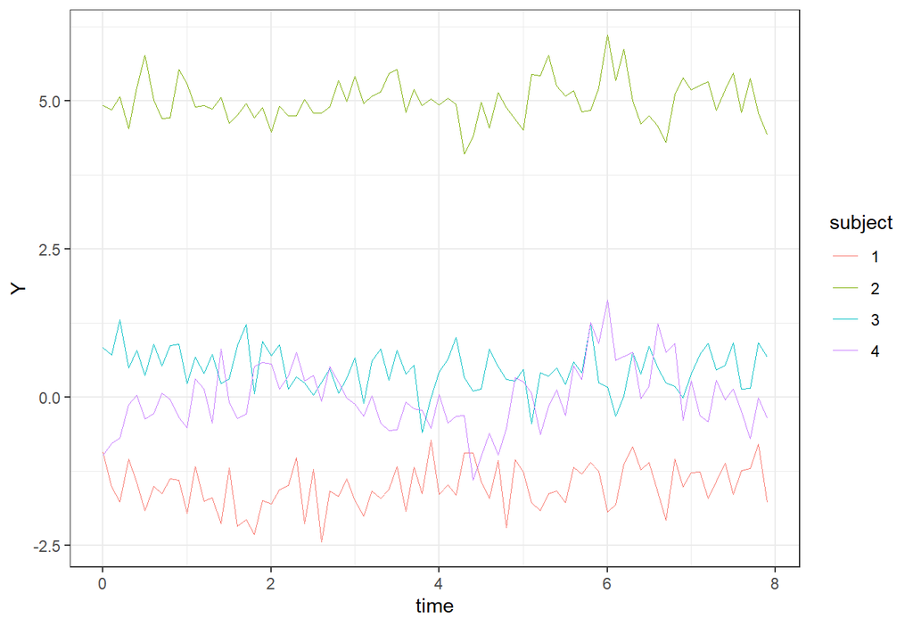

```r
ggplot(dat[dat$id <= 4, ], aes(time, Y, group = id, colour = factor(id))) +
  geom_line(linewidth = .35) + theme_bw()+
  labs(colour = "subject")
```

## Specify the fitted model

The same model object is used for the empirical Bayes and random-effects workflows. Random effects are requested on the four generating parameters. The empirical Bayes function internally removes those random effects for the per-subject fits, because each subject fit contains only one subject.

```r
fit_model <- ctModel(
  type = "ct",
  silent = TRUE,
  latentNames = "eta",
  manifestNames = "Y",
  LAMBDA = matrix(1),
  T0MEANS = matrix("t0m||TRUE", 1, 1),
  DRIFT = matrix("drift||TRUE", 1, 1),
  DIFFUSION = matrix("diffusion||TRUE", 1, 1),
  MANIFESTMEANS = matrix("mmean||TRUE", 1, 1),
  MANIFESTVAR = matrix("merror||FALSE", 1, 1)
)
```

## Empirical Bayes subject-wise fits

`ctEmpiricalBayesFit()` uses two subject-wise passes by default. First, it fits the model once per subject using the model prior. The raw estimates from these first-pass fits define the marginal empirical Bayes prior. Second, it rewrites the single-subject model transforms so raw `normal(0, 1)` parameters imply that empirical location and scale, then fits every subject again. The final `$fits` element contains the final EB-prior fits; `$initialfits` contains the model-prior fits, and `$passfits` contains every pass.

The transform adjustment is on the unconstrained raw scale. If the original model transforms a raw parameter $q$ to the model parameter $\theta$ as

$$\theta = f(q),$$

then the EB-adjusted model uses a new local raw parameter $z \sim N(0, 1)$ and sets

$$\theta = f(\mu_q + \sigma_q z),$$

where $\mu_q$ and $\sigma_q$ are the empirical mean and standard deviation of the subject-level raw estimates. For example, a positive parameter with `log1p_exp(param)` becomes `log1p_exp(mu + sigma * param)`.

If `Npasses > 2`, each later pass maps the local EB raw estimates back to the original raw scale before recomputing $\mu_q$ and $\sigma_q$. This gives an iterated marginal EB prior, but it still does not encode the empirical covariance among raw parameters.

By default, the EB prior construction is robust to extreme first-pass raw estimates: raw values are winsorized using quantile and MAD bounds, then the prior location and scale are computed with the median and MAD. This protects the second pass from a single subject fit with a very unusual optimum. Set `ebRobust = FALSE`, or adjust `ebOutlierQuantiles`, `ebOutlierMAD`, and `ebWinsorize`, if you want different behavior.

For optimized fits, the first pass uses `optimcontrol$estonly = TRUE`, because only point estimates are needed to build the EB prior. The stochastic optimizer is disabled by default for both passes; pass `optimcontrol = list(stochastic = TRUE)` if you want to override this.

```r
cores=2

eb_fit <- ctEmpiricalBayesFit(
  datalong = dat,
  model = fit_model,
  priors = TRUE,
  optimize = TRUE,
  cores = cores,
  Npasses = 2
)

eb_summary <- summary(eb_fit, use = "rawest", sdscale = "unit")

eb_summary$initialpopmeans
```

```
#>              mean     sd    2.5%     50%   97.5%
#> t0m       -0.0956 0.7227 -1.4298 -0.0897  1.0709
#> drift     -2.2049 1.4978 -5.2270 -1.9748 -0.2941
#> diffusion  0.5402 0.3394  0.0992  0.4454  1.1333
#> merror     0.3297 0.0492  0.2028  0.3401  0.3826
#> mmean     -0.6641 2.8957 -5.0221 -0.5457  4.7611
```

```r
eb_summary$outliers$initial
```

```
#>       param   lower   upper nlower nupper nchanged     action
#> 1       t0m -0.1430  0.1071      1      1        2 winsorized
#> 2     drift -1.2687  0.9213      1      1        2 winsorized
#> 3 diffusion -2.3137 -1.0648      1      1        2 winsorized
#> 4    merror -1.5959 -1.2659      1      1        2 winsorized
#> 5     mmean -0.5022  0.4761      1      1        2 winsorized
```

```r
eb_summary$popmeans
```

[output not shown]

```r
eb_summary$correlations$final
```

```
#>               t0m   drift diffusion  merror   mmean
#> t0m        1.0000  0.1465   -0.2513  0.0598  0.1936
#> drift      0.1465  1.0000   -0.1264 -0.3499 -0.3247
#> diffusion -0.2513 -0.1264    1.0000 -0.2983 -0.0719
#> merror     0.0598 -0.3499   -0.2983  1.0000 -0.0614
#> mmean      0.1936 -0.3247   -0.0719 -0.0614  1.0000
```

The summary is on the transformed parameter scale, matching the scale users usually inspect in `summary(ctFit(...))`. The EB covariance is summarized for inspection, but it is not encoded in the adjusted model. `eb_fit$adjustedmodel` is the random-effect-free single-subject model used for the final pass, with transforms based on marginal EB means and standard deviations only. The full subject fits and raw estimate matrices remain on `eb_fit`; `summary(eb_fit)` only returns compact summaries.

```r
eb_fit$adjustedmodel$pars[
  eb_fit$adjustedmodel$pars$param %in% c("t0m", "drift", "diffusion", "mmean"),
  c("matrix", "param", "transform", "indvarying", "sdscale")]
```

```
#>          matrix     param transform indvarying sdscale
#> 1       T0MEANS       t0m         0      FALSE       1
#> 3         DRIFT     drift         1      FALSE       1
#> 4     DIFFUSION diffusion         1      FALSE       1
#> 6 MANIFESTMEANS     mmean         0      FALSE       1
```

## Standard random-effects fit

For comparison, fit the same model as a conventional hierarchical random-effects model. This fit is independent of the empirical Bayes fits.

```r
re_fit <- ctFit(
  datalong = dat,
  model = fit_model,
  priors = TRUE,
  cores = cores
)
```

## Compare subject-level recovery

The empirical Bayes subject estimates below are separate per-subject estimates from the second pass, using the empirical prior learned from the first pass. The random-effects estimates are posterior subject parameters from the hierarchical fit.

```r
extract_subject_point <- function(fit){
  cp <- ctSummaryMatrices(fit)
  c(
    t0m = cp$T0MEANS["eta", 1],
    drift = cp$DRIFT["eta", "eta"],
    diffusion = cp$DIFFUSION["eta", "eta"],
    mmean = cp$MANIFESTMEANS["Y", 1]
  )
}

initial_subject <- do.call(rbind, lapply(eb_fit$initialfits,
  extract_subject_point))
eb_subject <- do.call(rbind, lapply(eb_fit$fits, extract_subject_point))

re_subject <- ctSubjectPars(re_fit, pointest = TRUE)[1, ,
  c("t0m", "drift", "diffusion", "mmean")]

truth_mat <- as.matrix(truth[, c("t0m", "drift", "diffusion", "mmean")])

recovery_summary <- function(est, truth){
  data.frame(
    param = colnames(truth),
    correlation = diag(stats::cor(est, truth)),
    rmse = sqrt(colMeans((est - truth)^2)),
    estimate_sd = apply(est, 2, sd),
    true_sd = apply(truth, 2, sd),
    row.names = NULL
  )
}
```

## Initial and final EB subject recovery

The first EB pass uses the model prior separately for each subject. The final EB pass uses the empirical marginal raw prior estimated from the preceding pass. This comparison isolates the effect of the EB prior update before adding the random-effects model to the comparison.

```r
eb_pass_recovery <- rbind(
  cbind(method = "Initial model-prior fits",
    recovery_summary(initial_subject, truth_mat)),
  cbind(method = "Final EB-prior fits",
    recovery_summary(eb_subject, truth_mat))
)

knitr::kable(eb_pass_recovery, digits = 3)
```

| method | param | correlation | rmse | estimate_sd | true_sd |
| --- | --- | --- | --- | --- | --- |
| Initial model-prior fits | t0m | 0.885 | 0.333 | 0.723 | 0.699 |
| Initial model-prior fits | drift | 0.087 | 1.897 | 1.498 | 0.389 |
| Initial model-prior fits | diffusion | 0.578 | 0.276 | 0.339 | 0.175 |
| Initial model-prior fits | mmean | 0.999 | 0.147 | 2.896 | 2.844 |
| Final EB-prior fits | t0m | 0.881 | 0.323 | 0.618 | 0.699 |
| Final EB-prior fits | drift | 0.127 | 1.296 | 0.951 | 0.389 |
| Final EB-prior fits | diffusion | 0.751 | 0.147 | 0.227 | 0.175 |
| Final EB-prior fits | mmean | 0.999 | 0.147 | 2.879 | 2.844 |

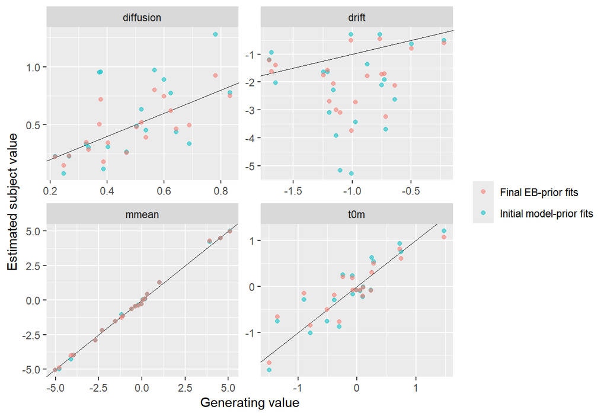

```r
eb_pass_plot_data <- rbind(
  data.frame(method = "Initial model-prior fits", id = truth$id,
    param = rep(colnames(truth_mat), each = n_subjects),
    true = as.vector(truth_mat),
    estimate = as.vector(initial_subject)),
  data.frame(method = "Final EB-prior fits", id = truth$id,
    param = rep(colnames(truth_mat), each = n_subjects),
    true = as.vector(truth_mat),
    estimate = as.vector(eb_subject))
)

ggplot(eb_pass_plot_data, aes(true, estimate, colour = method)) +
  geom_abline(slope = 1, intercept = 0, linewidth = .3) +
  geom_point(alpha = .55, size = 1.4) +
  facet_wrap(~ param, scales = "free") +
  labs(x = "Generating value", y = "Estimated subject value", colour = NULL)
```

## Correlation Recovery

There are two distinct correlation targets. The population raw random-effects correlation is on the pre-transformation scale, so it should be compared with the generating raw parameter correlations and with raw estimates. Subject-level parameter correlations are on the actual transformed parameter scale, so they should be compared with correlations among the generated `truth` values.

```r
lower_cor_table <- function(reference, estimates){
  lower <- lower.tri(reference)
  pair_index <- which(lower, arr.ind = TRUE)
  out <- data.frame(
    pair = paste(rownames(reference)[pair_index[, 1]],
      colnames(reference)[pair_index[, 2]], sep = "__"),
    truth = as.vector(reference[lower]),
    check.names = FALSE)
  for(nm in names(estimates)){
    out[[nm]] <- as.vector(estimates[[nm]][lower])
  }
  out
}

true_raw_cor <- stats::cor(as.matrix(raw_truth[, raw_param_names]))
initial_eb_raw_cor <- stats::cor(eb_fit$initialraw[, raw_param_names])
final_eb_raw_cor <- stats::cor(
  eb_fit$passoriginalraw[[length(eb_fit$passoriginalraw)]][, raw_param_names])

re_raw_names <- ctsem:::getparnames(re_fit, reonly = TRUE)
re_rawpopcorr <- re_fit$stanfit$transformedparsfull$rawpopcorr[1, , ]
dimnames(re_rawpopcorr) <- list(re_raw_names, re_raw_names)
re_rawpopcorr <- re_rawpopcorr[raw_param_names, raw_param_names]

raw_cor_recovery <- lower_cor_table(true_raw_cor, list(
  "Initial EB raw estimates" = initial_eb_raw_cor,
  "Final EB raw estimates" = final_eb_raw_cor,
  "Random-effects population raw" = re_rawpopcorr
))

knitr::kable(raw_cor_recovery, digits = 3)
```

| pair | truth | Initial EB raw estimates | Final EB raw estimates | Random-effects population raw |
| --- | --- | --- | --- | --- |
| drift__t0m | 0.737 | 0.184 | 0.187 | 0.111 |
| diffusion__t0m | -0.411 | -0.309 | -0.260 | -0.187 |
| mmean__t0m | 0.339 | 0.149 | 0.194 | -0.094 |
| diffusion__drift | -0.549 | -0.468 | -0.178 | 0.570 |
| mmean__drift | 0.338 | -0.402 | -0.294 | 0.049 |
| mmean__diffusion | -0.241 | -0.008 | -0.128 | -0.018 |

```r
true_subject_cor <- stats::cor(truth_mat)
initial_subject_cor <- stats::cor(initial_subject)
eb_subject_cor <- stats::cor(eb_subject)
re_subject_cor <- stats::cor(re_subject)

subject_cor_recovery <- lower_cor_table(true_subject_cor, list(
  "Initial EB subject values" = initial_subject_cor,
  "Final EB subject values" = eb_subject_cor,
  "Random-effects subject values" = re_subject_cor
))

knitr::kable(subject_cor_recovery, digits = 3)
```

| pair | truth | Initial EB subject values | Final EB subject values | Random-effects subject values |
| --- | --- | --- | --- | --- |
| drift__t0m | 0.709 | 0.133 | 0.136 | 0.241 |
| diffusion__t0m | -0.456 | -0.237 | -0.245 | -0.341 |
| mmean__t0m | 0.339 | 0.149 | 0.195 | 0.111 |
| diffusion__drift | -0.587 | -0.481 | -0.153 | 0.482 |
| mmean__drift | 0.335 | -0.436 | -0.332 | -0.033 |
| mmean__diffusion | -0.256 | 0.148 | -0.070 | -0.412 |

## Final EB and random-effects subject recovery

This comparison uses the final EB subject fits and the hierarchical random-effects subject estimates on the transformed parameter scale.

```r
recovery <- rbind(
  cbind(method = "EB subject fits", recovery_summary(eb_subject, truth_mat)),
  cbind(method = "Random effects", recovery_summary(re_subject, truth_mat))
)

knitr::kable(recovery, digits = 3)
```

| method | param | correlation | rmse | estimate_sd | true_sd |
| --- | --- | --- | --- | --- | --- |
| EB subject fits | t0m | 0.881 | 0.323 | 0.618 | 0.699 |
| EB subject fits | drift | 0.127 | 1.296 | 0.951 | 0.389 |
| EB subject fits | diffusion | 0.751 | 0.147 | 0.227 | 0.175 |
| EB subject fits | mmean | 0.999 | 0.147 | 2.879 | 2.844 |
| Random effects | t0m | 0.814 | 0.399 | 0.527 | 0.699 |
| Random effects | drift | 0.063 | 1.495 | 1.502 | 0.389 |
| Random effects | diffusion | 0.506 | 0.277 | 0.221 | 0.175 |
| Random effects | mmean | 0.995 | 0.279 | 2.913 | 2.844 |

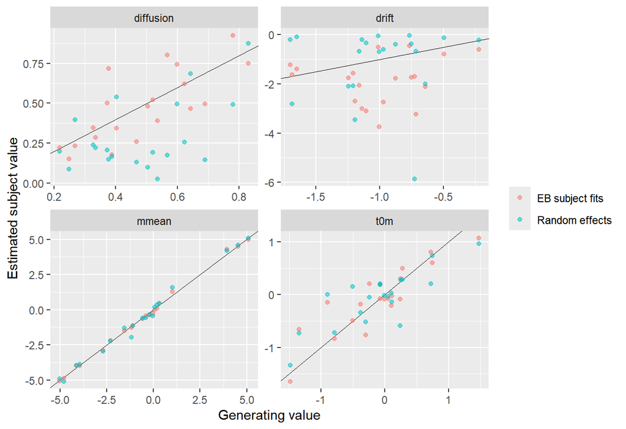

```r
plot_data <- rbind(
  data.frame(method = "EB subject fits", id = truth$id,
    param = rep(colnames(truth_mat), each = n_subjects),
    true = as.vector(truth_mat),
    estimate = as.vector(eb_subject)),
  data.frame(method = "Random effects", id = truth$id,
    param = rep(colnames(truth_mat), each = n_subjects),
    true = as.vector(truth_mat),
    estimate = as.vector(re_subject))
)

ggplot(plot_data, aes(true, estimate, colour = method)) +
  geom_abline(slope = 1, intercept = 0, linewidth = .3) +
  geom_point(alpha = .55, size = 1.4) +
  facet_wrap(~ param, scales = "free") +
  labs(x = "Generating value", y = "Estimated subject value", colour = NULL)
```